# sigident - Howto Microarray

The R package `sigident` is the core package of the `sigident` package framework. This framework consists of several packages which can be used to perform analyses of gene signatures. The following packages are included in the framework: * Core package: sigident * Data preprocessing: sigident.preproc * Functional analyses: sigident.func

# Prerequisites and installation

## Install sigident.preproc package

```r
options('repos' = 'https://ftp.fau.de/cran/')
install.packages("devtools")
devtools::install_git("https://gitlab.miracum.org/clearly/sigident.preproc.git",
                      upgrade = "always")
```

## Install sigident.func package

```r
devtools::install_git("https://gitlab.miracum.org/clearly/sigident.func.git",
                      upgrade = "always")
```

## Install sigident package

```r
devtools::install_git("https://gitlab.miracum.org/clearly/sigident.git")
```

# Preprocessing

In order to use this R package and its functions, you need to prepare a merged gene expression dataset. The workflow to achieve this is presented in the following by making use of the R package `sigident.preproc`.

For a more detailed background and description of the following steps please view the `sigident.preproc` package’s [vignette](https://github.com/miracum/clearly-sigident.preproc/blob/master/vignettes/sigident_preproc_Howto_GEO.Rmd).

## Initialization of important variables

```r
library(sigident)
library(sigident.preproc)
library(sigident.func)
library(knitr)
library(caret)

# initialize filePath:
filePath <- tempdir()

# define datadir
maindir <- "./geodata/"
datadir <- paste0(maindir, "data/")
dir.create(maindir)
dir.create(datadir)
```

```r
# define plotdir
plotdir <- "./plots/"
dir.create(plotdir)
# define idtype
idtype = "affy"
```

## Define list that contains a representation of the studies metadata

```r
studiesinfo <- list(
  "GSE18842" = list(
    setid = 1,
    targetcolname = "source_name_ch1",
    targetlevelname = "Human Lung Tumor",
    controllevelname = "Human Lung Control"
    ),

  "GSE19804" = list(
    setid = 1,
    targetcolname = "source_name_ch1",
    targetlevelname = "frozen tissue of primary tumor",
    controllevelname = "frozen tissue of adjacent normal"
  ),

  "GSE19188" = list(
    setid = 1,
    targetcolname = "characteristics_ch1",
    controllevelname = "tissue type: healthy",
    targetlevelname = "tissue type: tumor",
    use_rawdata = TRUE
  )
)
```

## Load GEO datasets

All downloaded datasets will be assigned to the global environment.

```r
sigident.preproc::load_geo_data(
  studiesinfo = studiesinfo,
  datadir = datadir,
  plotdir = plotdir,
  idtype = idtype,
  viz_batch_boxp = F,
  viz_batch_gpca = F
)
```

### Visualize batch effect

By using the argument `viz_batch_boxp = TRUE` and `viz_batch_gpca = TRUE`, one can visualize batch effects before and after correction with two methods: boxplots and gPCA and store them in the directory specified in `plotdir`. For further details please view the [vignette of the `sigident.preproc` R package](https://github.com/miracum/clearly-sigident.preproc/blob/master/vignettes/sigident_preproc_Howto_GEO.Rmd). Due to the resource-intensive calculations of the plots, this argument is set to FALSE here.

# Preparations for utilizing the sigident package

Before using the `sigident` package, these variables need to be defined properly. One could use them also as arguments directly in the respective function. However, to keep the code clearer we define them here at the beginning and refer at each function to the respective variable. `idtype` and `plotdir` have already been defined during the preprocessing steps.

In order to use this R package and its functions, you need to prepare a merged gene expression dataset. The workflow to achieve this is presented in the following by making use of the R package `sigident.preproc`.

For a detailed background on the following steps please view the `sigident.preproc` package’s [vignette](https://github.com/miracum/clearly-sigident.preproc/blob/master/vignettes/sigident_preproc_Howto_GEO.Rmd).

```r
# general
csvdir <- "./csv/"
dir.create(csvdir)
# enrichment analysis
species <- "Hs"
OrgDb <- "org.Hs.eg.db"
organism <- "hsa"
#pathwayid <- "hsa04110" # Cell Cycle
pathwayid <- "hsa04151" # PI3K-Akt

# diagnostic signature
seed <- 111
split <- 0.8
nfolds <- 10
ncores <- 4
```

# DEG analysis

For a detailed background and description of the following steps please view the [`sigident.func` package’s vignette](https://github.com/miracum/clearly-sigident.func/blob/master/vignettes/sigident_func_Howto_Functional.Rmd).

```r
# define the false discovery rate here
fdr <- 0.05

genes <- sigident.func::identify_degs(mergeset = mergeset,
                                      diagnosis = diagnosis,
                                      q_value = fdr)

# heatmap creation
filename <- paste0(plotdir, "DEG_heatmap.png")
# create colors for map
ht_colors <- sigident.func::color_heatmap(sample_metadata = sample_metadata)
sigident.func::plot_deg_heatmap(mergeset = mergeset,
                                genes = genes,
                                patientcolors = ht_colors,
                                filename = filename)
```

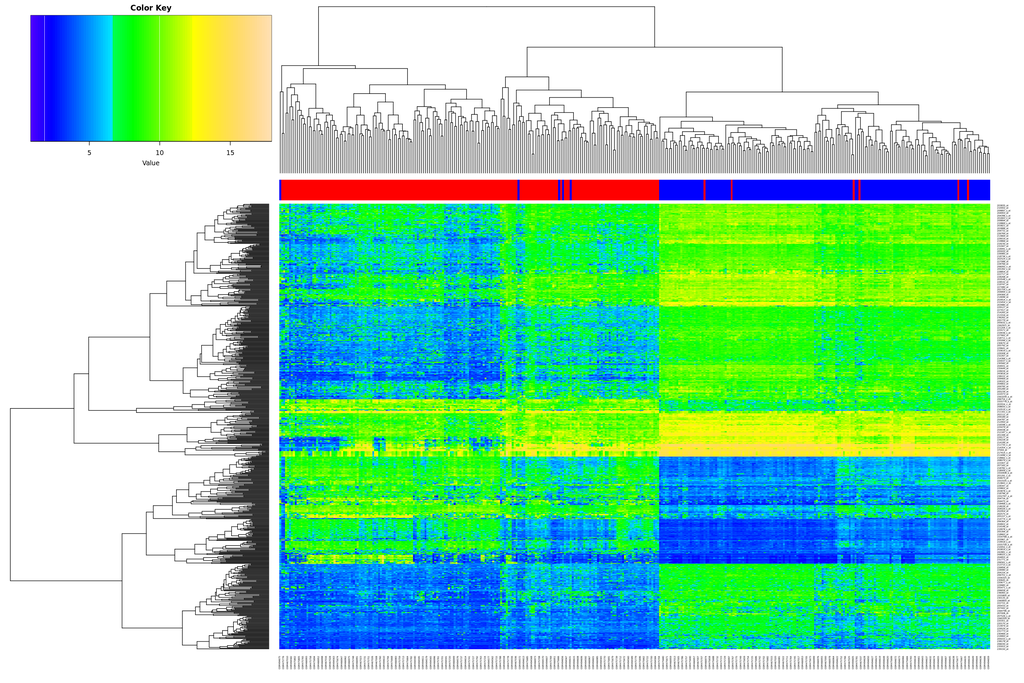

```r
knitr::include_graphics(filename)
```

```r
deg_info <- sigident.func::export_deg_annotations(mergedset = mergedset,
                                                  genes = genes,
                                                  idtype = idtype)
data.table::fwrite(deg_info, paste0(csvdir, "DEG_info.csv"))
```

```r
dim(deg_info)
```

```
#> [1] 699   5
```

```r
knitr::kable(head(deg_info))
```

| probe_ID | gene_symbol | gene_title | genebank_accession | entrez_id |
| --- | --- | --- | --- | --- |
| 1552318_at | GIMAP1 | GTPase, IMAP family member 1 | AK091818 | 170575 |
| 1552509_a_at | CD300LG | CD300 molecule-like family member g | NM_145273 | 146894 |
| 1552619_a_at | ANLN | anillin, actin binding protein | NM_018685 | 54443 |
| 1552767_a_at | HS6ST2 | heparan sulfate 6-O-sulfotransferase 2 | NM_147174 | 90161 |
| 1552797_s_at | PROM2 | prominin 2 | NM_144707 | 150696 |
| 1553105_s_at | DSG2 | desmoglein 2 | NM_001943 | 1829 |

```r
deg_results <- sigident.func::limma_top_table(mergeset = mergeset,
                                              diagnosis = diagnosis,
                                              q_value = fdr)
data.table::fwrite(deg_results, paste0(csvdir, "DEG_results.csv"))
```

```r
dim(deg_results)
```

```
#> [1] 699   3
```

```r
knitr::kable(head(deg_results))
```

|  | Probe ID | logFC | adj.q_value |
| --- | --- | --- | --- |
| 217046_s_at | 217046_s_at | -4.210369 | 0 |
| 210081_at | 210081_at | -5.357893 | 0 |
| 209470_s_at | 209470_s_at | -4.554050 | 0 |
| 209469_at | 209469_at | -3.945921 | 0 |
| 206209_s_at | 206209_s_at | -4.396693 | 0 |
| 209904_at | 209904_at | -4.090450 | 0 |

```r
rm(deg_info, deg_results, studiesinfo)
gc()
```

# Functional analysis

## Gene enrichment

For a detailed background and description of the following steps please view the `sigident.func` package’s [vignette](https://github.com/miracum/clearly-sigident.func/blob/master/vignettes/sigident_func_Howto_Functional.Rmd).

```r
deg_entrez <- unique(mergedset@featureData@data$ENTREZ_GENE_ID)
deg_entrez <- deg_entrez[deg_entrez != ""]
```

## Test for over-representation

```r
enr_topgo <- sigident.func::extract_go_terms(gene = deg_entrez,
                                             species = species)
data.table::fwrite(enr_topgo, paste0(csvdir, "Top_GO.csv"))
```

```r
dim(enr_topgo)
```

```
#> [1] 20  5
```

```r
knitr::kable(head(enr_topgo))
```

|  | Term | Ont | N | DE | P.DE |
| --- | --- | --- | --- | --- | --- |
| GO:0005737 | cytoplasm | CC | 11311 | 10438 | 0 |
| GO:0005515 | protein binding | MF | 11806 | 11015 | 0 |
| GO:0005488 | binding | MF | 15264 | 13660 | 0 |
| GO:0003674 | molecular_function | MF | 17696 | 15487 | 0 |
| GO:0005622 | intracellular | CC | 14888 | 13094 | 0 |
| GO:0043226 | organelle | CC | 14137 | 12433 | 0 |

```r
enr_topkegg <- sigident.func::extract_kegg_terms(gene = deg_entrez,
                                                 species = species)
data.table::fwrite(enr_topkegg, paste0(csvdir, "Top_KEGG.csv"))
```

```r
dim(enr_topkegg)
```

```
#> [1] 20  4
```

```r
knitr::kable(head(enr_topkegg))
```

|  | Pathway | N | DE | P.DE |
| --- | --- | --- | --- | --- |
| path:hsa05200 | Pathways in cancer | 531 | 515 | 0 |
| path:hsa01100 | Metabolic pathways | 1492 | 1383 | 0 |
| path:hsa05132 | Salmonella infection | 213 | 210 | 0 |
| path:hsa04151 | PI3K-Akt signaling pathway | 354 | 341 | 0 |
| path:hsa05165 | Human papillomavirus infection | 331 | 319 | 0 |
| path:hsa04360 | Axon guidance | 181 | 179 | 0 |

```r
enr_fitlm <- sigident.func::go_diff_reg(
  mergeset = mergeset,
  idtype = idtype,
  diagnosis = diagnosis,
  entrezids = mergedset@featureData@data$ENTREZ_GENE_ID
)

enr_fitlm_topgo <- sigident.func::extract_go_terms(
  gene = enr_fitlm,
  species = species,
  fdr = 0.01
)
data.table::fwrite(enr_fitlm_topgo, paste0(csvdir, "Top_GO_fitlm.csv"))
```

```r
dim(enr_fitlm_topgo)
```

```
#> [1] 20  7
```

```r
knitr::kable(head(enr_fitlm_topgo))
```

|  | Term | Ont | N | Up | Down | P.Up | P.Down |
| --- | --- | --- | --- | --- | --- | --- | --- |
| GO:0043231 | intracellular membrane-bounded organelle | CC | 9865 | 4893 | 3404 | 0 | 0 |
| GO:0070013 | intracellular organelle lumen | CC | 4979 | 2784 | 1708 | 0 | 0 |
| GO:0031974 | membrane-enclosed lumen | CC | 4979 | 2784 | 1708 | 0 | 0 |
| GO:0043233 | organelle lumen | CC | 4979 | 2784 | 1708 | 0 | 0 |
| GO:0005622 | intracellular | CC | 13094 | 6142 | 4661 | 0 | 0 |
| GO:0043227 | membrane-bounded organelle | CC | 11459 | 5485 | 4044 | 0 | 0 |

```r
enr_fitlm_topkegg <- sigident.func::extract_kegg_terms(
  gene = enr_fitlm,
  species = species
)
data.table::fwrite(enr_fitlm_topkegg, paste0(csvdir, "Top_KEGG_fitlm.csv"))
```

```r
dim(enr_fitlm_topkegg)
```

```
#> [1] 20  6
```

```r
knitr::kable(head(enr_fitlm_topkegg))
```

|  | Pathway | N | Up | Down | P.Up | P.Down |
| --- | --- | --- | --- | --- | --- | --- |
| path:hsa05132 | Salmonella infection | 210 | 79 | 132 | 0.9901820 | 0.0000000 |
| path:hsa05016 | Huntington disease | 283 | 200 | 83 | 0.0000000 | 0.8937705 |
| path:hsa05014 | Amyotrophic lateral sclerosis | 338 | 231 | 115 | 0.0000000 | 0.3041530 |
| path:hsa03013 | RNA transport | 148 | 117 | 43 | 0.0000000 | 0.8436476 |
| path:hsa05200 | Pathways in cancer | 515 | 230 | 258 | 0.6344687 | 0.0000000 |
| path:hsa04380 | Osteoclast differentiation | 126 | 37 | 86 | 0.9999171 | 0.0000000 |

## GO enrichment analysis

```r
enr_analysis <- sigident.func::go_enrichment_analysis(
  gene = deg_entrez,
  org_db = OrgDb,
  organism = organism,
  fitlm = enr_fitlm,
  pathwayid = pathwayid,
  species = organism,
  plotdir = plotdir
)
```

```r
filename <- paste0(plotdir, "/", pathwayid, ".png")
```

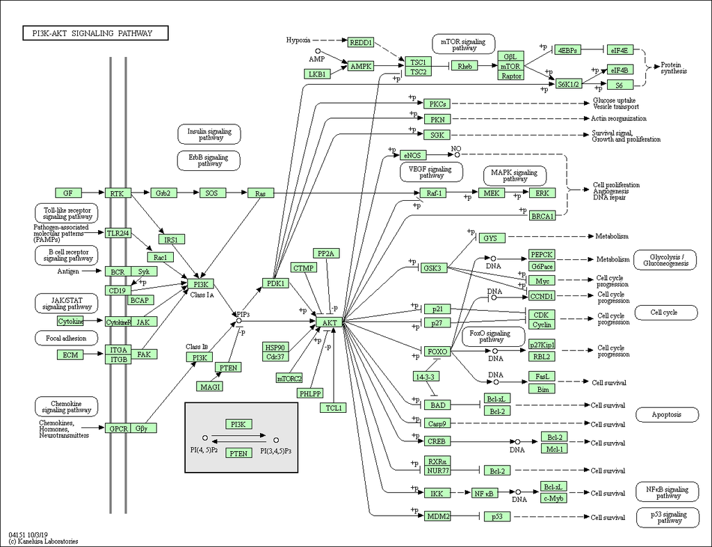

```r
knitr::include_graphics(filename)
```

```r
filename <- paste0(plotdir, "/", pathwayid, ".pathview.png")
```

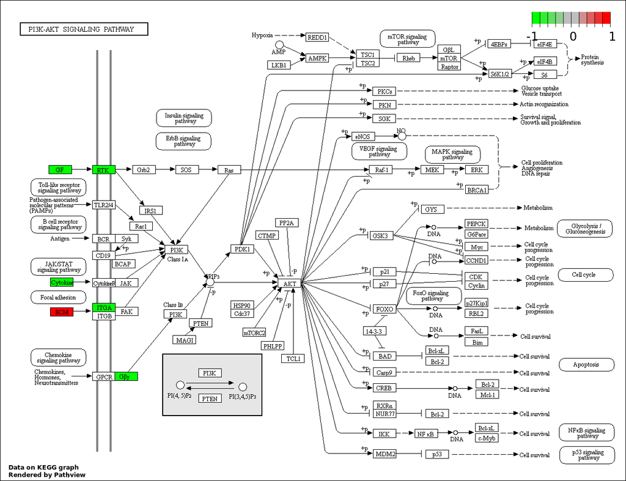

```r
knitr::include_graphics(filename)
```

```r
filename <- paste0(plotdir, "Enriched_GO.png")
sigident.func::plot_enriched_barplot(
  enrichmentobj = enr_analysis$go,
  type = "GO",
  filename = filename
)
```

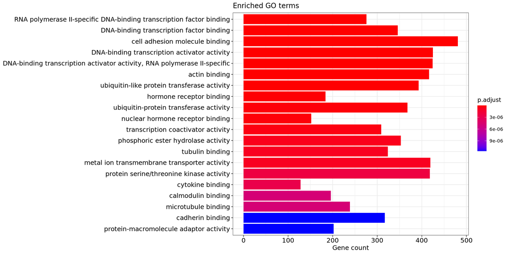

```r
knitr::include_graphics(filename)
```

```r
filename <- paste0(plotdir, "Enriched_KEGG.png")
sigident.func::plot_enriched_barplot(
  enrichmentobj = enr_analysis$kegg,
  type = "KEGG",
  filename = filename
)
```

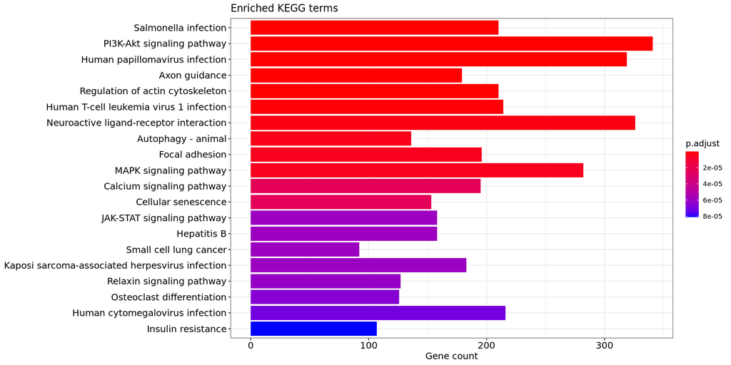

```r
knitr::include_graphics(filename)
```

```r
rm(bods, enr_analysis, enr_fitlm, enr_fitlm_topgo, enr_fitlm_topkegg,
   enr_topgo, enr_topkegg, gene.idtype.bods, korg, cpd.simtypes,
   deg_entrez, gene.idtype.list, ht_colors, mergedset)
gc()
```

# Identification of diagnostic signatures

A common task regarding gene expression data is to distinguish between different groups or subtypes. In order to train a multi-gene classifier, a large amount of expression data is required. Due to the imbalance of features (p) versus observations (n), the application of an appropriate method is needed.  
The lasso regression and elastic net regularization are generalized linear models which are powerful and versatile methods for feature selection and are well suited in order to analyse genomic data with p >> n.  
Therefore, we implemented the elastic net regularization method for the identification of a diagnostic multi-gene signature.

## Split data into training and test dataset

A statistical prediction model is usually trained on 70%-80% percent of the present data. `create_training_test_split` randomly splits the merged dataset into a training and a test set with the former defined value `split` regarding to a balanced distribution of the groups (here diagnosis). For reproducibility, a seed must be set.

```r
training_list <- sigident::create_training_test_split(
  diagnosis = diagnosis,
  mergeset = mergeset,
  split = split,
  seed = seed
)
```

For demonstration/ runtime purposes, the data is reduced to the first 300 genes. If you want to run the analyses on the whole dataset, please comment out the following lines.

```r
training_list$train$x <- training_list$train$x[, 1:300]
training_list$test$x <- training_list$test$x[, 1:300]
```

## Lasso regression

Regularization requires the selection of a tuning parameter (lambda) that determines the strength of regularization. The function `signature` performs an `nfolds` cross-validation to select the best lambda and additionally builds the predictive model. `seed` is again set for reproducibility. The plot depicts the mean squared error as the criterion for the 10-fold cross-validation and shows the optimal values of lambda and the appropriate number of selected features (genes) above the plot. The left dashed vertical line represents the log of the optimal value of lambda (‘lambda min’), which results in the lowest prediction error and giving the most accurate model. The right dashed vertical line indicates the log of the lambda value resulting in a model with the smallest number of included variables but also lies within one standard error of the optimal value of lambda (‘lambda 1se’).  
Furthermore, a ROC curve is plotted to visualize the performance measurement of the model.

```r
diagnostic_lasso <- sigident::sigident_signature(
  traininglist = training_list,
  type = "lasso",
  nfolds = nfolds,
  seed = seed,
  ncores = ncores
)
filename <- paste0(plotdir, "CV_lasso.png")
sigident::plot_cvplot(cv_obj = diagnostic_lasso$fit_cv,
                      filename = filename)
```

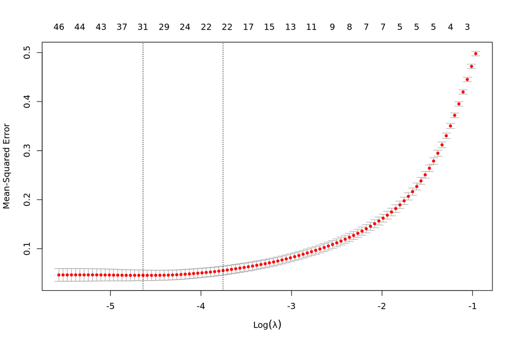

```r
knitr::include_graphics(filename)
```

```r
filename <- paste0(plotdir, "ROC_Lasso.min.png")
sigident::plot_rocplot(roc = diagnostic_lasso$roc_min,
                       filename = filename)
```

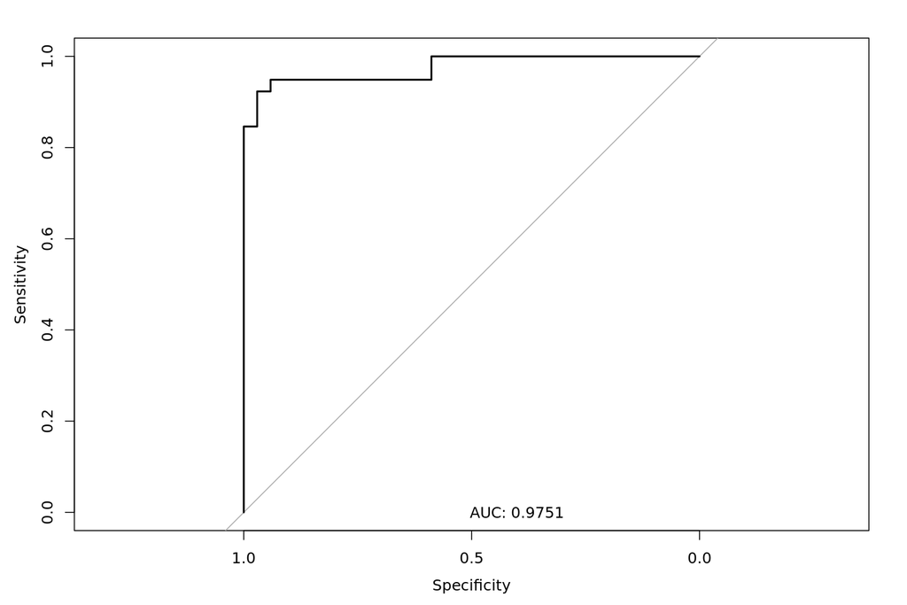

```r
knitr::include_graphics(filename)
```

```r
filename <- paste0(plotdir, "ROC_Lasso.1se.png")
sigident::plot_rocplot(roc = diagnostic_lasso$roc_1se,
                       filename = filename)
```

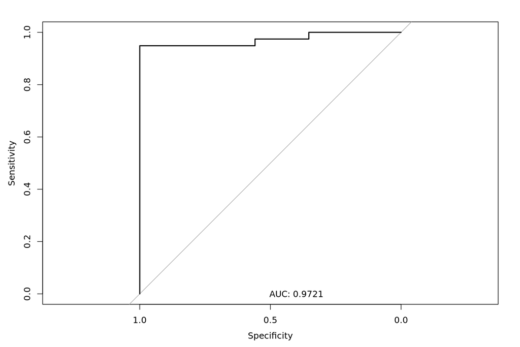

```r
knitr::include_graphics(filename)
```

## Elastic net regression

The elastic net is a mixture of lasso and ridge regularization to shrink coefficients (like in ridge regression) and to set some coefficients to zero (as in lasso). Therefore, the mixing parameter alpha needs to be determined as value between 1 (for lasso) and 0 (for ridge). A grid search for calculating optimal alpha and lambda can be conducted (as it is done next) but might take much computing capacity, hence we propose setting alpha manually to 0.9.

```r
diagnostic_elasticnet <- sigident::sigident_signature(
  traininglist = training_list,
  type = "elastic",
  a = 0.9,
  nfolds = nfolds,
  seed = seed,
  ncores = ncores
)
filename <- paste0(plotdir, "CV_elasticNet.png")
sigident::plot_cvplot(cv_obj = diagnostic_elasticnet$fit_cv,
                      filename = filename)
```

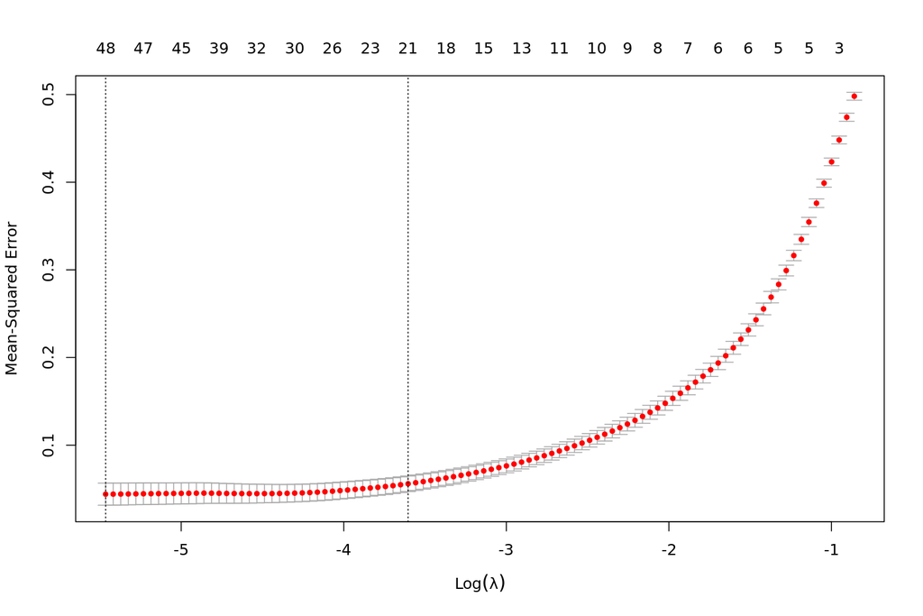

```r
knitr::include_graphics(filename)
```

```r
filename <- paste0(plotdir, "ROC_elasticNet.min.png")
sigident::plot_rocplot(roc = diagnostic_elasticnet$roc_min,
                       filename = filename)
```

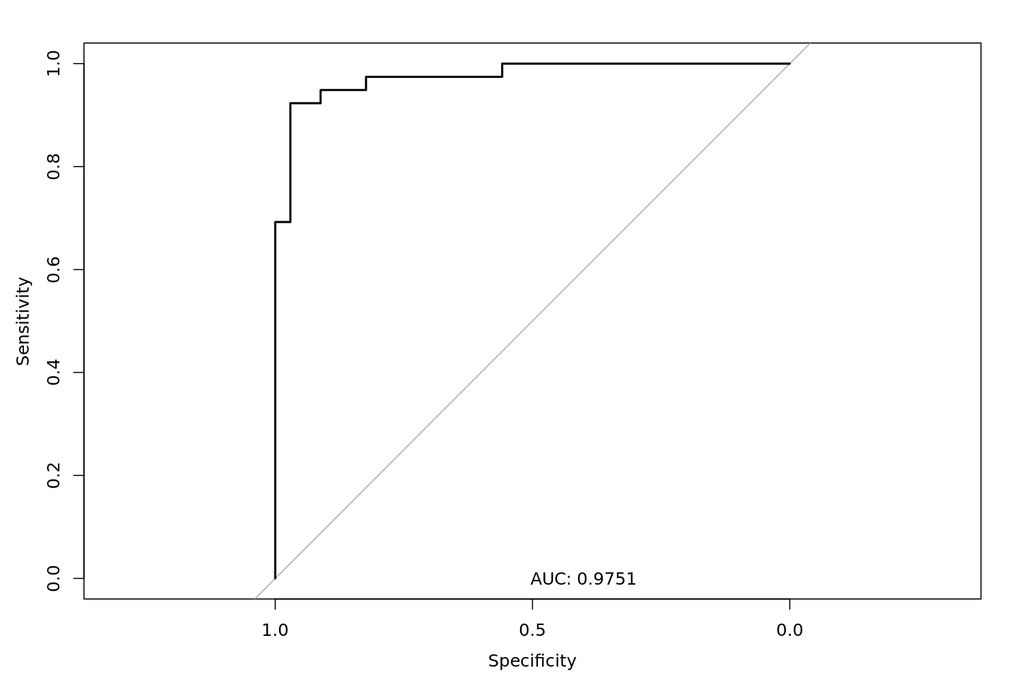

```r
knitr::include_graphics(filename)
```

```r
filename <- paste0(plotdir, "ROC_elasticNet.1se.png")
sigident::plot_rocplot(roc = diagnostic_elasticnet$roc_1se,
                       filename = filename)
```

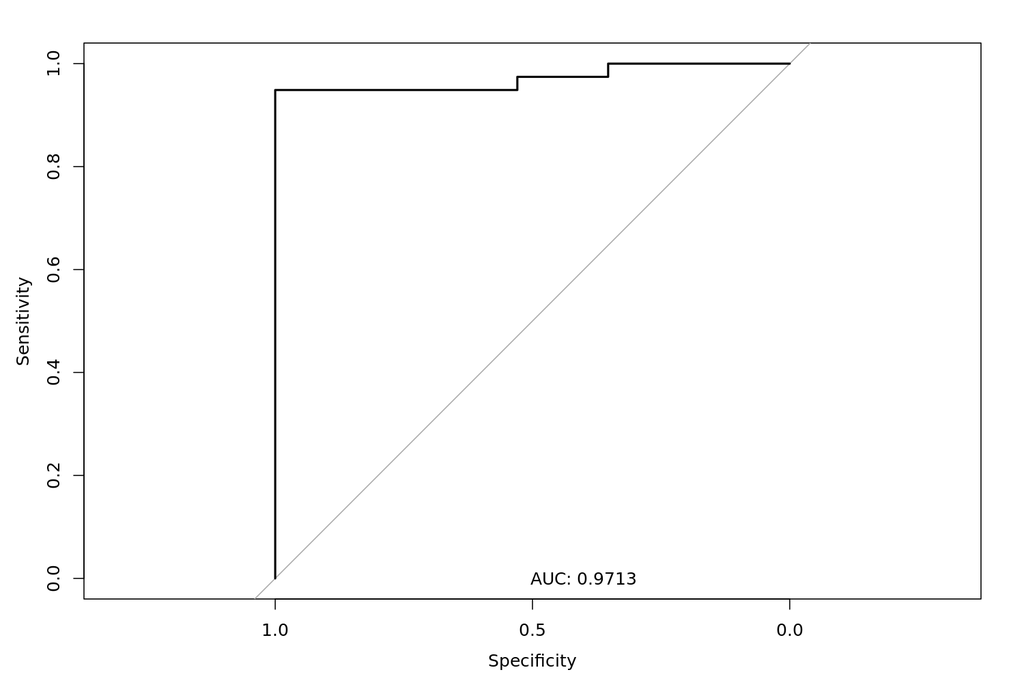

```r
knitr::include_graphics(filename)
```

## Gridsearch to find alpha and lambda

Setting `type = "glmnet"` of the function `signature` conducts a grid search calculating a pair of alpha and lambda for the ‘glmnet’-method, that minimizes the CV error, using the R package caret.

```r
diagnostic_glmgrid <- sigident::sigident_signature(
  traininglist = training_list,
  type = "glmnet",
  nfolds = nfolds,
  seed = seed,
  ncores = ncores
)
# plot model of gridsearch
filename <- paste0(plotdir, "Gridsearch_model.png")
sigident::plot_grid_model_plot(model = diagnostic_glmgrid$model,
                               filename = filename)
```

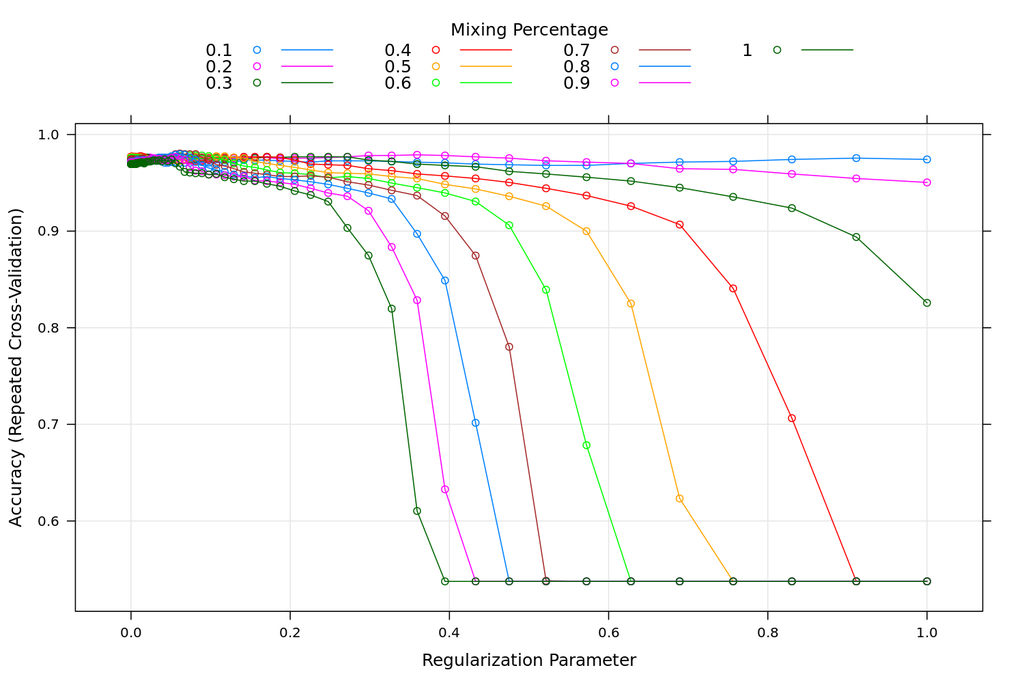

```r
knitr::include_graphics(filename)
```

```r
# plot variable importance of gridsearch
filename <- paste0(plotdir, "Elasticnet_Gridsearch_var_imp.png")
sigident::plot_grid_varimp_plot(model = diagnostic_glmgrid$model,
                                filename = filename)
```

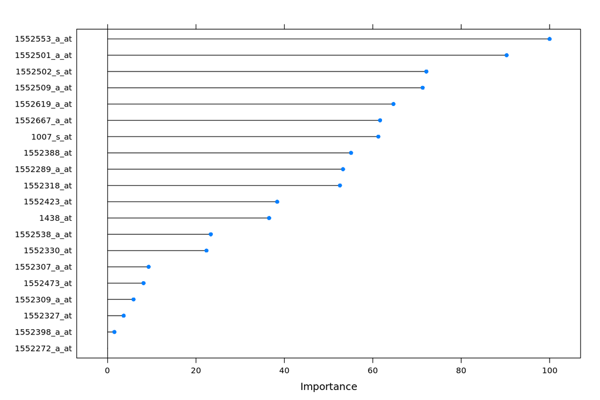

```r
knitr::include_graphics(filename)
```

```r
# create roc plot
filename <- paste0(plotdir, "ROC_elasticNet.grid.png")
sigident::plot_rocplot(roc = diagnostic_glmgrid$roc,
                       filename = filename)
```

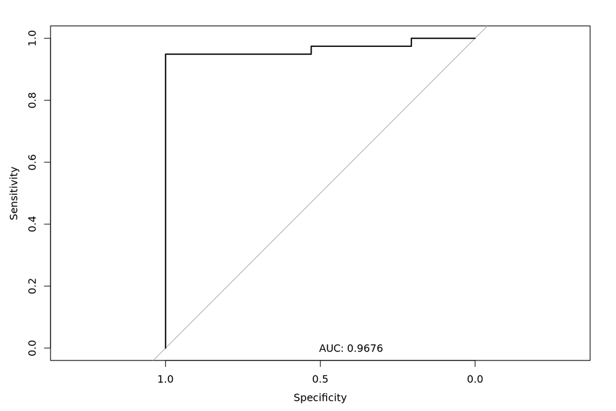

```r
knitr::include_graphics(filename)
```

## SVM

A support vector machine is a collection of supervised learning algorithms that use hyperplane graphing to analyze new, unlabeled data. In Support Vector Machine incoming data is categorized into one of two classes. For SVM models, each data point is interpreted as a p-dimensional vector, which the machine attempts to create a linear classifier by fitting the data point inside a hyperplane (p-1 dimension). So for classification, every input is turned into a point in n-dimensional space (n being the number of features), and the value of each feature defined as the value of a unique coordinate on the hyperplane. Classification is determined by finding the hyperplane that most clearly separates the two classes.

```r
diagnostic_svm <- sigident::sigident_signature(
  traininglist = training_list,
  type = "svm",
  nfolds = nfolds,
  seed = seed,
  ncores = ncores
)
gc();gc();
filename <- paste0(plotdir, "SVM_model.png")
sigident::plot_grid_model_plot(
    model = diagnostic_svm$model,
    filename = filename
)
```

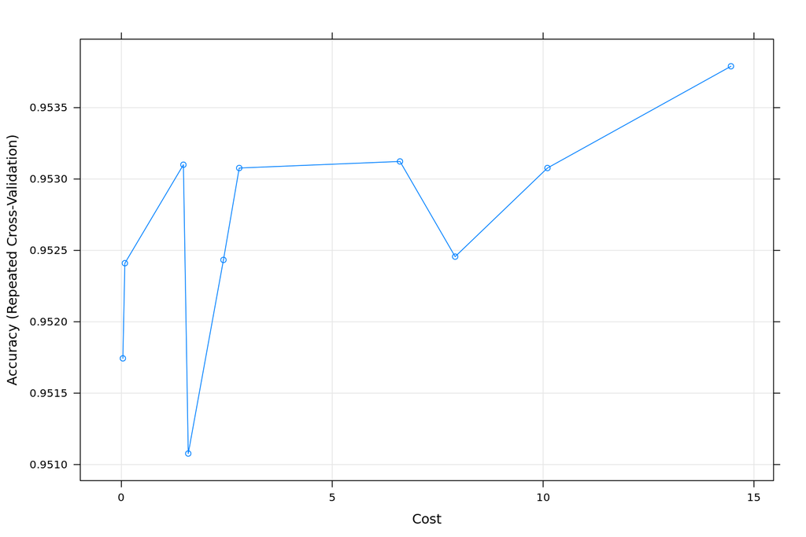

```r
knitr::include_graphics(filename)
```

```r
filename <- paste0(plotdir, "SVM_variable_importance.png")
sigident::plot_grid_varimp_plot(
    model = diagnostic_svm$model,
    filename = filename
)
```

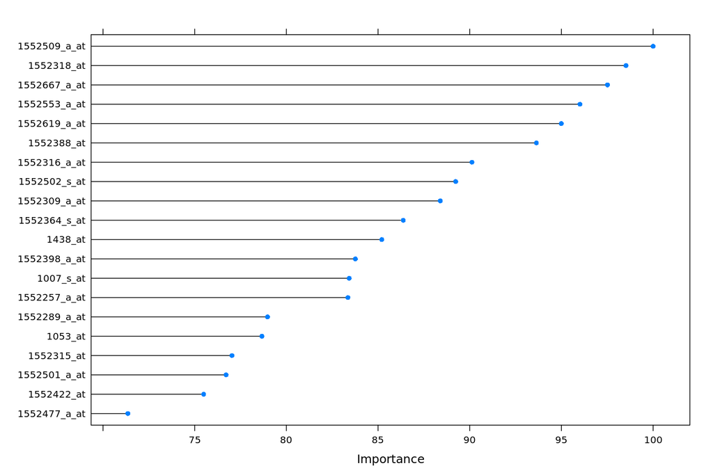

```r
knitr::include_graphics(filename)
```

```r
filename <- paste0(plotdir, "ROC_SVM.png")
sigident::plot_rocplot(
    roc = diagnostic_svm$roc,
    filename = filename
)
gc();gc();
```

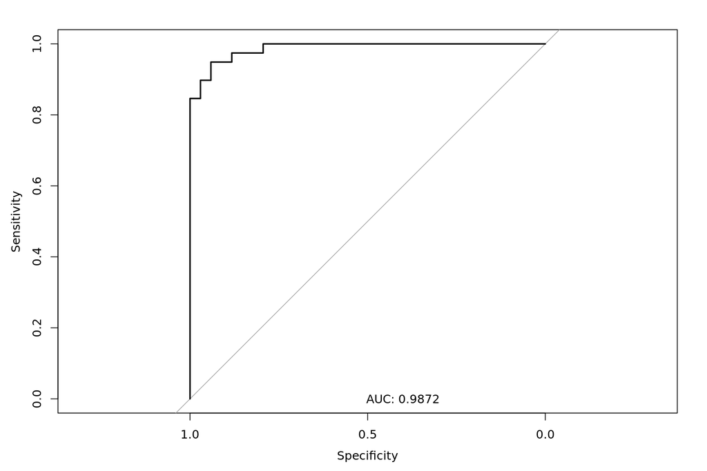

```r
knitr::include_graphics(filename)
```

## Random Forest

The random forest is a supervised learning algorithm that randomly creates and merges multiple decision trees into one forest. The goal is not to rely on a single learning model, but rather a collection of decision models to improve accuracy. The primary difference between this approach and the standard decision tree algorithms is that the root nodes feature splitting nodes are generated randomly.

```r
diagnostic_rf <- sigident::sigident_signature(
  traininglist = training_list,
  type = "rf",
  nfolds = nfolds,
  seed = seed,
  ncores = ncores
)
gc();gc();
filename <- paste0(plotdir, "RF_model.png")
sigident::plot_grid_model_plot(
    model = diagnostic_rf$model,
    filename = filename
)
```

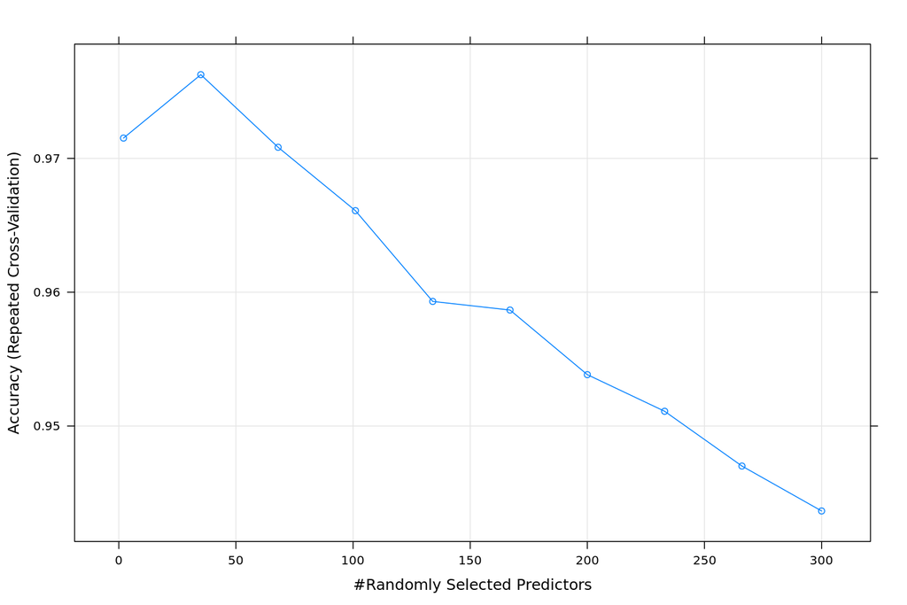

```r
knitr::include_graphics(filename)
```

```r
filename <- paste0(plotdir, "RF_variable_importance.png")
sigident::plot_grid_varimp_plot(
    model = diagnostic_rf$model,
    filename = filename
)
```

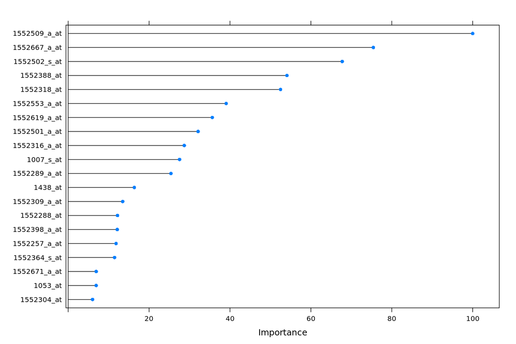

```r
knitr::include_graphics(filename)
```

```r
filename <- paste0(plotdir, "ROC_RF.png")
sigident::plot_rocplot(
    roc = diagnostic_rf$roc,
    filename = filename
)
```

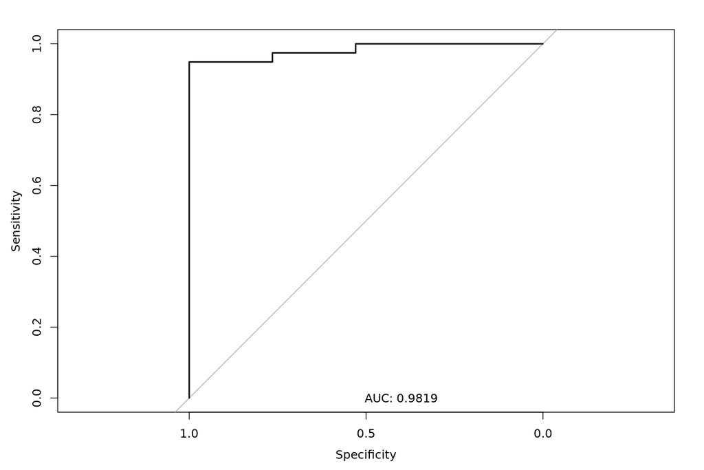

```r
knitr::include_graphics(filename)
```

## K-Nearest Neighbors

```r
diagnostic_knn <- sigident::sigident_signature(
  traininglist = training_list,
  type = "knn",
  nfolds = nfolds,
  seed = seed,
  ncores = ncores
)
filename <- paste0(plotdir, "KNN_model.png")
sigident::plot_grid_model_plot(
    model = diagnostic_knn$model,
    filename = filename
)
```

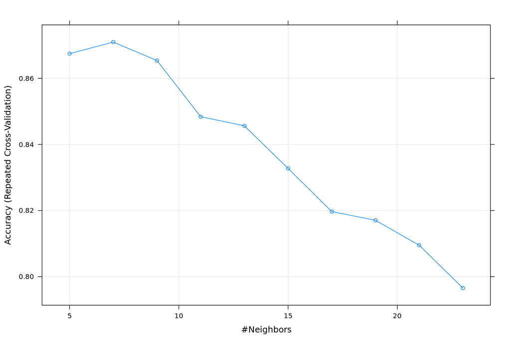

```r
knitr::include_graphics(filename)
```

```r
filename <- paste0(plotdir, "KNN_variable_importance.png")
sigident::plot_grid_varimp_plot(
    model = diagnostic_knn$model,
    filename = filename
)
```

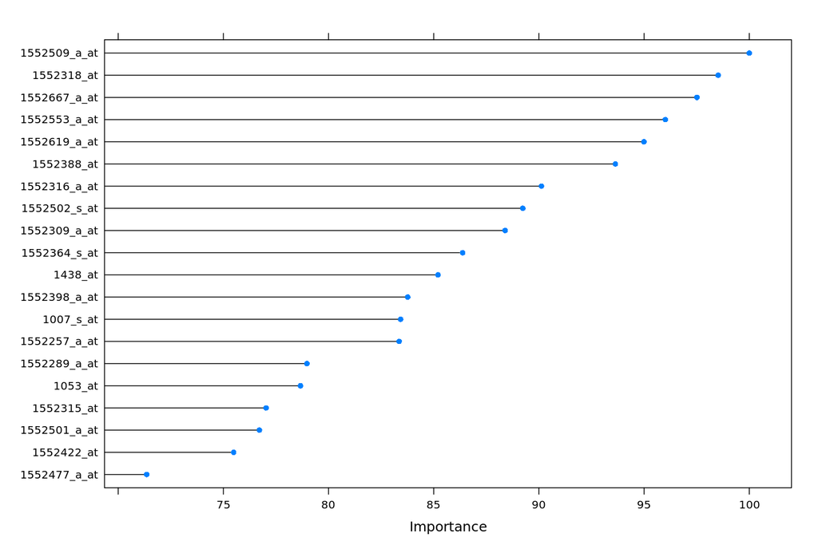

```r
knitr::include_graphics(filename)
```

```r
filename <- paste0(plotdir, "ROC_KNN.png")
sigident::plot_rocplot(
    roc = diagnostic_knn$roc,
    filename = filename
)
```

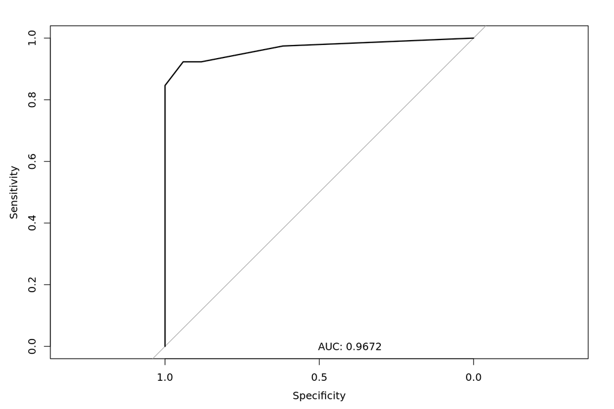

```r
knitr::include_graphics(filename)
```

## Analysis of diagnostic models

### Comparing model performance

These models can be included into a list and the performance metrices for classification can then be printed using the function `compare_diagnostic_models()`. This list includes all information of the respective models, which can be accessed by the following structure.

```r
diagnostic_models <- list(

  "lasso" = list(
    "CV" = diagnostic_lasso$fit_cv,
    "min" = list("model" = diagnostic_lasso$lambda_min,
                 "confmat" = diagnostic_lasso$confmat_min,
                 "prediction" = diagnostic_lasso$prediction_min,
                 "auc" = as.numeric(diagnostic_lasso$roc_min$auc)
                 ),
    "1se" = list("model" = diagnostic_lasso$lambda_1se,
                 "confmat" = diagnostic_lasso$confmat_1se,
                 "prediction" = diagnostic_lasso$prediction_1se,
                 "auc" = as.numeric(diagnostic_lasso$roc_1se$auc)
                 )
  ),

  "elasticnet" = list(
    "CV" = diagnostic_elasticnet$fit_cv,
    "min" = list("model" = diagnostic_elasticnet$lambda_min,
                 "confmat" = diagnostic_elasticnet$confmat_min,
                 "prediction" = diagnostic_elasticnet$prediction_min,
                 "auc" = as.numeric(diagnostic_elasticnet$roc_min$auc)
                 ),
    "1se" = list("model" = diagnostic_elasticnet$lambda_1se,
                 "confmat" = diagnostic_elasticnet$confmat_1se,
                 "prediction" = diagnostic_elasticnet$prediction_1se,
                 "auc" = as.numeric(diagnostic_elasticnet$roc_1se$auc)
                 )
  ),

  "glmnet" = list(
    "model" = diagnostic_glmgrid$model,
    "confmat" = diagnostic_glmgrid$confmat,
    "prediction" = diagnostic_glmgrid$prediction,
    "auc" = as.numeric(diagnostic_glmgrid$roc$auc)
    ),

  "svm" = list(
      "model" = diagnostic_svm$model,
      "confmat" = diagnostic_svm$confmat,
      "prediction" = diagnostic_svm$prediction,
      "auc" = as.numeric(diagnostic_svm$roc$auc)
  ),

  "rf" = list(
    "model" = diagnostic_rf$model,
    "confmat" = diagnostic_rf$confmat,
    "prediction" = diagnostic_rf$prediction,
    "auc" = as.numeric(diagnostic_rf$roc$auc)
  ),

  "knn" = list(
    "model" = diagnostic_knn$model,
    "confmat" = diagnostic_knn$confmat,
    "prediction" = diagnostic_knn$prediction,
    "auc" = as.numeric(diagnostic_knn$roc$auc)
  )
)
```

```r
knitr::kable(
  sigident::compare_diagnostic_models(diagnostic_models)
)
```

| Model | AUC |
| --- | --- |
| lasso.min | 0.975 |
| lasso.1se | 0.972 |
| elasticnet.min | 0.975 |
| elasticnet.1se | 0.971 |
| glmnet | 0.968 |
| svm | 0.987 |
| rf | 0.982 |
| knn | 0.967 |

```r
rm(diagnostic_glmgrid, diagnostic_elasticnet, diagnostic_lasso,
   diagnostic_svm, diagnostic_knn, diagnostic_rf,
   training_list)
gc()
```

### Extract lambda values

A function `get_diagnostic_lambda_values` was designed, to extract the results of the cross validation.

```r
knitr::kable(
  sigident::get_diagnostic_lambda_values(diagnostic_models)
)
```

| Model | Lambda min | Lambda 1se |
| --- | --- | --- |
| lasso | 0.009660 | 0.023378 |
| elasticnet | 0.004233 | 0.027212 |
| glmnet (best tune: alpha, lambda) | 0.700000 | 0.061359 |

### Model performance measurements

Additionally, the confusion matrix and the calculated performance metrics can be printed out for each model.

#### Lasso (min)

```r
diagnostic_models$lasso$min$confmat
```

```
#> Confusion Matrix and Statistics
#>
#>           Reference
#> Prediction  0  1
#>          0 31  2
#>          1  3 37
#>
#>                Accuracy : 0.9315
#>                  95% CI : (0.8474, 0.9774)
#>     No Information Rate : 0.5342
#>     P-Value [Acc > NIR] : 1.099e-13
#>
#>                   Kappa : 0.8621
#>
#>  Mcnemar's Test P-Value : 1
#>
#>             Sensitivity : 0.9487
#>             Specificity : 0.9118
#>          Pos Pred Value : 0.9250
#>          Neg Pred Value : 0.9394
#>              Prevalence : 0.5342
#>          Detection Rate : 0.5068
#>    Detection Prevalence : 0.5479
#>       Balanced Accuracy : 0.9302
#>
#>        'Positive' Class : 1
#>
```

#### Lasso (1se)

```r
diagnostic_models$lasso[["1se"]]$confmat
```

```
#> Confusion Matrix and Statistics
#>
#>           Reference
#> Prediction  0  1
#>          0 31  2
#>          1  3 37
#>
#>                Accuracy : 0.9315
#>                  95% CI : (0.8474, 0.9774)
#>     No Information Rate : 0.5342
#>     P-Value [Acc > NIR] : 1.099e-13
#>
#>                   Kappa : 0.8621
#>
#>  Mcnemar's Test P-Value : 1
#>
#>             Sensitivity : 0.9487
#>             Specificity : 0.9118
#>          Pos Pred Value : 0.9250
#>          Neg Pred Value : 0.9394
#>              Prevalence : 0.5342
#>          Detection Rate : 0.5068
#>    Detection Prevalence : 0.5479
#>       Balanced Accuracy : 0.9302
#>
#>        'Positive' Class : 1
#>
```

#### Elastic (min)

```r
diagnostic_models$elasticnet$min$confmat
```

```
#> Confusion Matrix and Statistics
#>
#>           Reference
#> Prediction  0  1
#>          0 32  3
#>          1  2 36
#>
#>                Accuracy : 0.9315
#>                  95% CI : (0.8474, 0.9774)
#>     No Information Rate : 0.5342
#>     P-Value [Acc > NIR] : 1.099e-13
#>
#>                   Kappa : 0.8626
#>
#>  Mcnemar's Test P-Value : 1
#>
#>             Sensitivity : 0.9231
#>             Specificity : 0.9412
#>          Pos Pred Value : 0.9474
#>          Neg Pred Value : 0.9143
#>              Prevalence : 0.5342
#>          Detection Rate : 0.4932
#>    Detection Prevalence : 0.5205
#>       Balanced Accuracy : 0.9321
#>
#>        'Positive' Class : 1
#>
```

#### Elastic (1se)

```r
diagnostic_models$elasticnet[["1se"]]$confmat
```

```
#> Confusion Matrix and Statistics
#>
#>           Reference
#> Prediction  0  1
#>          0 31  2
#>          1  3 37
#>
#>                Accuracy : 0.9315
#>                  95% CI : (0.8474, 0.9774)
#>     No Information Rate : 0.5342
#>     P-Value [Acc > NIR] : 1.099e-13
#>
#>                   Kappa : 0.8621
#>
#>  Mcnemar's Test P-Value : 1
#>
#>             Sensitivity : 0.9487
#>             Specificity : 0.9118
#>          Pos Pred Value : 0.9250
#>          Neg Pred Value : 0.9394
#>              Prevalence : 0.5342
#>          Detection Rate : 0.5068
#>    Detection Prevalence : 0.5479
#>       Balanced Accuracy : 0.9302
#>
#>        'Positive' Class : 1
#>
```

#### Elastic net (grid search)

```r
diagnostic_models$glmnet$confmat
```

```
#> Confusion Matrix and Statistics
#>
#>           Reference
#> Prediction  0  1
#>          0 32  2
#>          1  2 37
#>
#>                Accuracy : 0.9452
#>                  95% CI : (0.8656, 0.9849)
#>     No Information Rate : 0.5342
#>     P-Value [Acc > NIR] : 8.964e-15
#>
#>                   Kappa : 0.8899
#>
#>  Mcnemar's Test P-Value : 1
#>
#>             Sensitivity : 0.9487
#>             Specificity : 0.9412
#>          Pos Pred Value : 0.9487
#>          Neg Pred Value : 0.9412
#>              Prevalence : 0.5342
#>          Detection Rate : 0.5068
#>    Detection Prevalence : 0.5342
#>       Balanced Accuracy : 0.9449
#>
#>        'Positive' Class : 1
#>
```

#### SVM

```r
diagnostic_models$svm$confmat
```

```
#> Confusion Matrix and Statistics
#>
#>           Reference
#> Prediction  0  1
#>          0 32  2
#>          1  2 37
#>
#>                Accuracy : 0.9452
#>                  95% CI : (0.8656, 0.9849)
#>     No Information Rate : 0.5342
#>     P-Value [Acc > NIR] : 8.964e-15
#>
#>                   Kappa : 0.8899
#>
#>  Mcnemar's Test P-Value : 1
#>
#>             Sensitivity : 0.9487
#>             Specificity : 0.9412
#>          Pos Pred Value : 0.9487
#>          Neg Pred Value : 0.9412
#>              Prevalence : 0.5342
#>          Detection Rate : 0.5068
#>    Detection Prevalence : 0.5342
#>       Balanced Accuracy : 0.9449
#>
#>        'Positive' Class : 1
#>
```

#### RF

```r
diagnostic_models$rf$confmat
```

```
#> Confusion Matrix and Statistics
#>
#>           Reference
#> Prediction  0  1
#>          0 32  2
#>          1  2 37
#>
#>                Accuracy : 0.9452
#>                  95% CI : (0.8656, 0.9849)
#>     No Information Rate : 0.5342
#>     P-Value [Acc > NIR] : 8.964e-15
#>
#>                   Kappa : 0.8899
#>
#>  Mcnemar's Test P-Value : 1
#>
#>             Sensitivity : 0.9487
#>             Specificity : 0.9412
#>          Pos Pred Value : 0.9487
#>          Neg Pred Value : 0.9412
#>              Prevalence : 0.5342
#>          Detection Rate : 0.5068
#>    Detection Prevalence : 0.5342
#>       Balanced Accuracy : 0.9449
#>
#>        'Positive' Class : 1
#>
```

#### KNN

```r
diagnostic_models$knn$confmat
```

```
#> Confusion Matrix and Statistics
#>
#>           Reference
#> Prediction  0  1
#>          0 32  3
#>          1  2 36
#>
#>                Accuracy : 0.9315
#>                  95% CI : (0.8474, 0.9774)
#>     No Information Rate : 0.5342
#>     P-Value [Acc > NIR] : 1.099e-13
#>
#>                   Kappa : 0.8626
#>
#>  Mcnemar's Test P-Value : 1
#>
#>             Sensitivity : 0.9231
#>             Specificity : 0.9412
#>          Pos Pred Value : 0.9474
#>          Neg Pred Value : 0.9143
#>              Prevalence : 0.5342
#>          Detection Rate : 0.4932
#>    Detection Prevalence : 0.5205
#>       Balanced Accuracy : 0.9321
#>
#>        'Positive' Class : 1
#>
```

### Export selected IDs for some models

The following function enables the extraction of the selected genes (Affy-IDs) for each model as csv file.

```r
signaturegenes <- sigident::gene_map_sig(
  mergeset = mergeset,
  model = diagnostic_models$lasso$min$model
)
data.table::fwrite(signaturegenes,
                   paste0(csvdir, "signaturegenes_lasso_min.csv"))
```

```r
signaturegenes <- sigident::gene_map_sig(
  mergeset = mergeset,
  model = diagnostic_models$lasso[["1se"]]$model
)
data.table::fwrite(signaturegenes,
                   paste0(csvdir, "signaturegenes_lasso_1se.csv"))
```

```r
signaturegenes <- sigident::gene_map_sig(
  mergeset = mergeset,
  model = diagnostic_models$elasticnet$min$model
)
data.table::fwrite(signaturegenes,
                   paste0(csvdir, "signaturegenes_elasticnet_min.csv"))
```

```r
signaturegenes <- sigident::gene_map_sig(
  mergeset = mergeset,
  model = diagnostic_models$elasticnet[["1se"]]$model
)
data.table::fwrite(signaturegenes,
                   paste0(csvdir, "signaturegenes_elasticnet_1se.csv"))
```

```r
rm(signaturegenes)
gc()
```

## Validation of diagnostic signatures

The validation of diagnostic signatures is conducted using the independent expression datasets of the studies “GSE30219”, “GSE33356” and “GSE102287”. We therefore need to create a list, holding meta information about the respective studies.

You have to create a list that contains specifications of the validation studies. The object must be named. The list structure is as follows:  
* `studyname`: the GEO id of the validation study  
+ `setid`: the index of the provided GEO set to be used  
+ `targetcolname`: the name of the phenoData column containing the target-variable  
+ `controllevelname`: the level name of the controls of the column, specified in `targetcolname`  
+ `targetlevelname`: the level name of the subjects of interest in `targetcolname`

```r
validationstudylist <- list(
  "GSE30219" = list(
    setid = 1,
    targetcolname = "source_name_ch1",
    controllevelname = "Non Tumoral Lung",
    targetlevelname = "Lung Tumour"
  ),
  "GSE33356" = list(
    setid = 1,
    targetcolname = "characteristics_ch1",
    controllevelname = "tissue: paired normal adjacent",
    targetlevelname = "tissue: lung cancer"
  ),
  "GSE102287" = list(
    setid = 2,
    targetcolname = "characteristics_ch1.6",
    controllevelname = "tumor_normal status: N",
    targetlevelname = "tumor_normal status: T"
  )
)
```

All models can be provided via the argument ‘model’ to the function `sigident::validate_diagnostic_signatures` using the previously created list `diagnostic_models`.

To perform the validation of the diagnostic signatures, simply run the function `sigident::validate_diagnostic_signatures` with the specified `validationstudylist`.

```r
# define gene subset
colindices <- 1:300
```

```r
validation_results <- sigident::validate_diagnostic_signatures(
  validationstudylist = validationstudylist,
  models = diagnostic_models,
  genes = genes,
  idtype = idtype,
  datadir = datadir,
  colindices = colindices
)
```

#### Lasso (min)

```r
validation_results[["GSE30219"]]$lasso$min$confmat
```

```
#> Confusion Matrix and Statistics
#>
#>           Reference
#> Prediction   0   1
#>          0  13  13
#>          1   1 280
#>
#>                Accuracy : 0.9544
#>                  95% CI : (0.9247, 0.9748)
#>     No Information Rate : 0.9544
#>     P-Value [Acc > NIR] : 0.570456
#>
#>                   Kappa : 0.6279
#>
#>  Mcnemar's Test P-Value : 0.003283
#>
#>             Sensitivity : 0.9556
#>             Specificity : 0.9286
#>          Pos Pred Value : 0.9964
#>          Neg Pred Value : 0.5000
#>              Prevalence : 0.9544
#>          Detection Rate : 0.9121
#>    Detection Prevalence : 0.9153
#>       Balanced Accuracy : 0.9421
#>
#>        'Positive' Class : 1
#>
```

```r
# create roc plot
filename <- paste0(plotdir, "ROC_validation_GSE30219_lasso_min.png")
sigident::plot_rocplot(roc = validation_results[["GSE30219"]]$lasso$min$roc,
                       filename = filename)
```

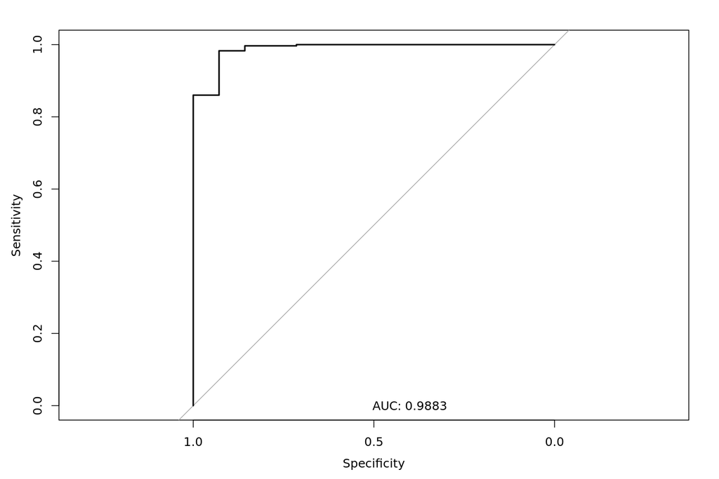

```r
knitr::include_graphics(filename)
```

#### Lasso (1se)

```r
validation_results[["GSE30219"]]$lasso[["1se"]]$confmat
```

```
#> Confusion Matrix and Statistics
#>
#>           Reference
#> Prediction   0   1
#>          0  12   5
#>          1   2 288
#>
#>                Accuracy : 0.9772
#>                  95% CI : (0.9536, 0.9908)
#>     No Information Rate : 0.9544
#>     P-Value [Acc > NIR] : 0.02887
#>
#>                   Kappa : 0.7623
#>
#>  Mcnemar's Test P-Value : 0.44969
#>
#>             Sensitivity : 0.9829
#>             Specificity : 0.8571
#>          Pos Pred Value : 0.9931
#>          Neg Pred Value : 0.7059
#>              Prevalence : 0.9544
#>          Detection Rate : 0.9381
#>    Detection Prevalence : 0.9446
#>       Balanced Accuracy : 0.9200
#>
#>        'Positive' Class : 1
#>
```

```r
# create roc plot
filename <- paste0(plotdir, "ROC_validation_GSE30219_lasso_1se.png")
sigident::plot_rocplot(roc = validation_results[["GSE30219"]]$lasso[["1se"]]$roc,
                       filename = filename)
```

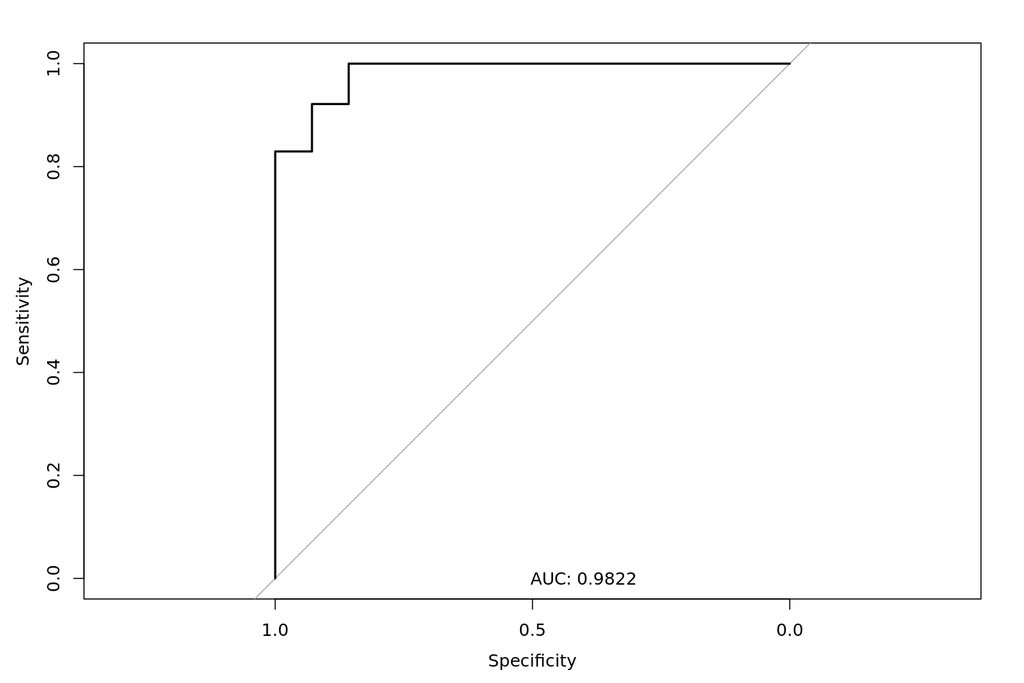

```r
knitr::include_graphics(filename)
```

#### Elastic (min)

```r
validation_results[["GSE30219"]]$elasticnet$min$confmat
```

```
#> Confusion Matrix and Statistics
#>
#>           Reference
#> Prediction   0   1
#>          0  12   4
#>          1   2 289
#>
#>                Accuracy : 0.9805
#>                  95% CI : (0.9579, 0.9928)
#>     No Information Rate : 0.9544
#>     P-Value [Acc > NIR] : 0.01268
#>
#>                   Kappa : 0.7898
#>
#>  Mcnemar's Test P-Value : 0.68309
#>
#>             Sensitivity : 0.9863
#>             Specificity : 0.8571
#>          Pos Pred Value : 0.9931
#>          Neg Pred Value : 0.7500
#>              Prevalence : 0.9544
#>          Detection Rate : 0.9414
#>    Detection Prevalence : 0.9479
#>       Balanced Accuracy : 0.9217
#>
#>        'Positive' Class : 1
#>
```

```r
# create roc plot
filename <- paste0(plotdir, "ROC_validation_GSE30219_elasticnet_min.png")
sigident::plot_rocplot(roc = validation_results[["GSE30219"]]$elasticnet$min$roc,
                       filename = filename)
```

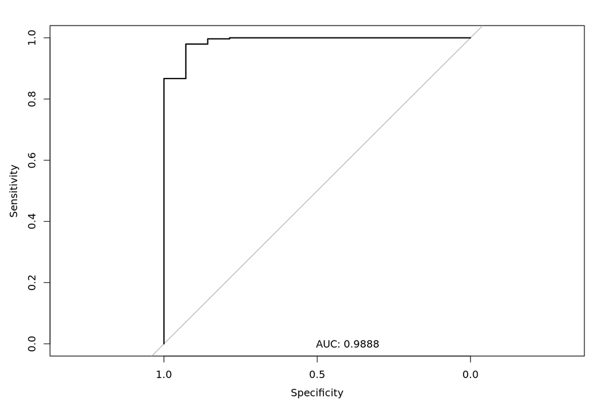

```r
knitr::include_graphics(filename)
```

#### Elastic (1se)

```r
validation_results[["GSE30219"]]$elasticnet[["1se"]]$confmat
```

```
#> Confusion Matrix and Statistics
#>
#>           Reference
#> Prediction   0   1
#>          0  12   5
#>          1   2 288
#>
#>                Accuracy : 0.9772
#>                  95% CI : (0.9536, 0.9908)
#>     No Information Rate : 0.9544
#>     P-Value [Acc > NIR] : 0.02887
#>
#>                   Kappa : 0.7623
#>
#>  Mcnemar's Test P-Value : 0.44969
#>
#>             Sensitivity : 0.9829
#>             Specificity : 0.8571
#>          Pos Pred Value : 0.9931
#>          Neg Pred Value : 0.7059
#>              Prevalence : 0.9544
#>          Detection Rate : 0.9381
#>    Detection Prevalence : 0.9446
#>       Balanced Accuracy : 0.9200
#>
#>        'Positive' Class : 1
#>
```

```r
# create roc plot
filename <- paste0(plotdir, "ROC_validation_GSE30219_elasticnet_1se.png")
sigident::plot_rocplot(roc = validation_results[["GSE30219"]]$elasticnet[["1se"]]$roc,
                       filename = filename)
```

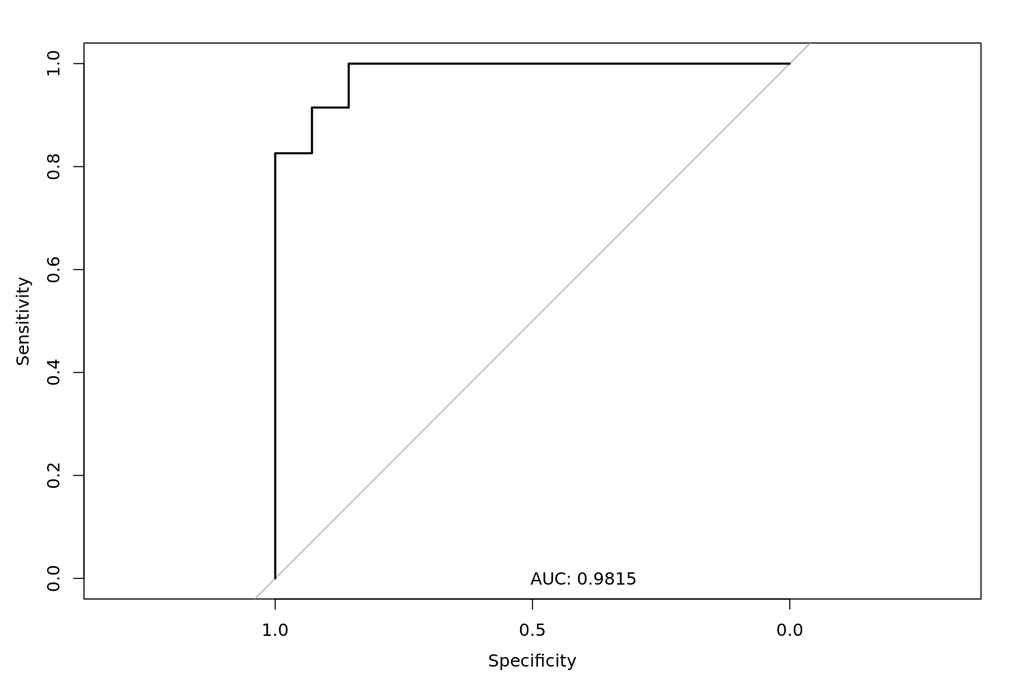

```r
knitr::include_graphics(filename)
```

#### Elasticnet gridsearch (best model)

```r
validation_results[["GSE30219"]]$glmnet$confmat
```

```
#> Confusion Matrix and Statistics
#>
#>           Reference
#> Prediction   0   1
#>          0  12   4
#>          1   2 289
#>
#>                Accuracy : 0.9805
#>                  95% CI : (0.9579, 0.9928)
#>     No Information Rate : 0.9544
#>     P-Value [Acc > NIR] : 0.01268
#>
#>                   Kappa : 0.7898
#>
#>  Mcnemar's Test P-Value : 0.68309
#>
#>             Sensitivity : 0.9863
#>             Specificity : 0.8571
#>          Pos Pred Value : 0.9931
#>          Neg Pred Value : 0.7500
#>              Prevalence : 0.9544
#>          Detection Rate : 0.9414
#>    Detection Prevalence : 0.9479
#>       Balanced Accuracy : 0.9217
#>
#>        'Positive' Class : 1
#>
```

```r
# create roc plot
filename <- paste0(plotdir, "ROC_validation_GSE30219_glmnet.png")
sigident::plot_rocplot(roc = validation_results[["GSE30219"]]$glmnet$roc,
                       filename = filename)
```

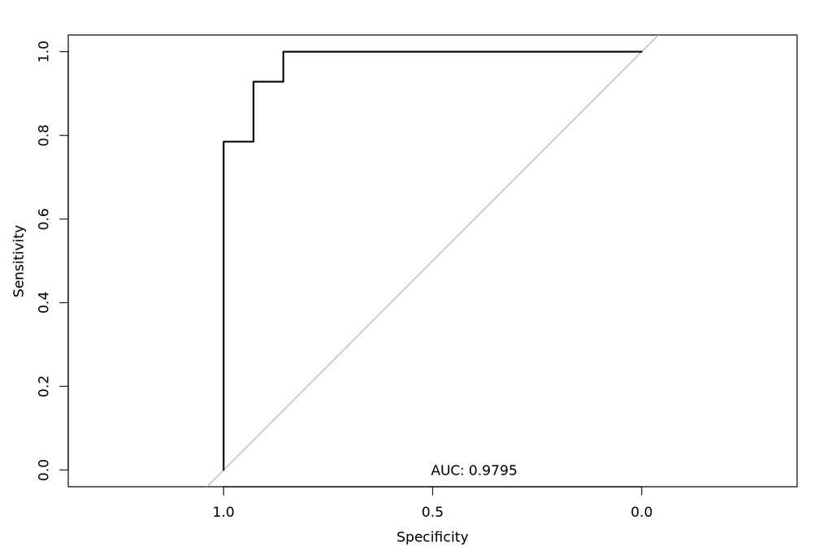

```r
knitr::include_graphics(filename)
```

#### SVM

```r
validation_results[["GSE30219"]]$svm$confmat
```

```
#> Confusion Matrix and Statistics
#>
#>           Reference
#> Prediction   0   1
#>          0  13  16
#>          1   1 277
#>
#>                Accuracy : 0.9446
#>                  95% CI : (0.9128, 0.9674)
#>     No Information Rate : 0.9544
#>     P-Value [Acc > NIR] : 0.832231
#>
#>                   Kappa : 0.5787
#>
#>  Mcnemar's Test P-Value : 0.000685
#>
#>             Sensitivity : 0.9454
#>             Specificity : 0.9286
#>          Pos Pred Value : 0.9964
#>          Neg Pred Value : 0.4483
#>              Prevalence : 0.9544
#>          Detection Rate : 0.9023
#>    Detection Prevalence : 0.9055
#>       Balanced Accuracy : 0.9370
#>
#>        'Positive' Class : 1
#>
```

```r
# create roc plot
filename <- paste0(plotdir, "ROC_validation_GSE30219_svm.png")
sigident::plot_rocplot(roc = validation_results[["GSE30219"]]$svm$roc,
                       filename = filename)
```

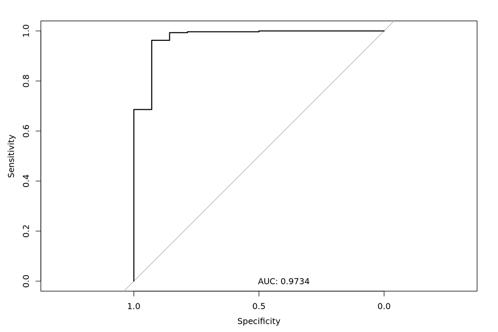

```r
knitr::include_graphics(filename)
```

#### RF

```r
validation_results[["GSE30219"]]$rf$confmat
```

```
#> Confusion Matrix and Statistics
#>
#>           Reference
#> Prediction   0   1
#>          0  12   2
#>          1   2 291
#>
#>                Accuracy : 0.987
#>                  95% CI : (0.967, 0.9964)
#>     No Information Rate : 0.9544
#>     P-Value [Acc > NIR] : 0.001517
#>
#>                   Kappa : 0.8503
#>
#>  Mcnemar's Test P-Value : 1.000000
#>
#>             Sensitivity : 0.9932
#>             Specificity : 0.8571
#>          Pos Pred Value : 0.9932
#>          Neg Pred Value : 0.8571
#>              Prevalence : 0.9544
#>          Detection Rate : 0.9479
#>    Detection Prevalence : 0.9544
#>       Balanced Accuracy : 0.9252
#>
#>        'Positive' Class : 1
#>
```

```r
# create roc plot
filename <- paste0(plotdir, "ROC_validation_GSE30219_rf.png")
sigident::plot_rocplot(roc = validation_results[["GSE30219"]]$rf$roc,
                       filename = filename)
```

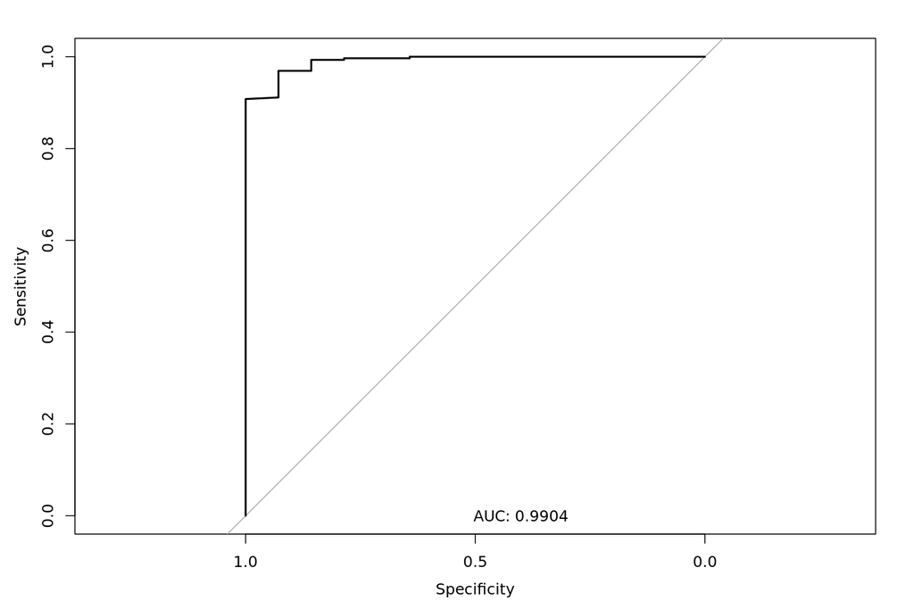

```r
knitr::include_graphics(filename)
```

#### KNN

```r
validation_results[["GSE30219"]]$knn$confmat
```

```
#> Confusion Matrix and Statistics
#>
#>           Reference
#> Prediction   0   1
#>          0  14 104
#>          1   0 189
#>
#>                Accuracy : 0.6612
#>                  95% CI : (0.6053, 0.714)
#>     No Information Rate : 0.9544
#>     P-Value [Acc > NIR] : 1
#>
#>                   Kappa : 0.1422
#>
#>  Mcnemar's Test P-Value : <2e-16
#>
#>             Sensitivity : 0.6451
#>             Specificity : 1.0000
#>          Pos Pred Value : 1.0000
#>          Neg Pred Value : 0.1186
#>              Prevalence : 0.9544
#>          Detection Rate : 0.6156
#>    Detection Prevalence : 0.6156
#>       Balanced Accuracy : 0.8225
#>
#>        'Positive' Class : 1
#>
```

```r
# create roc plot
filename <- paste0(plotdir, "ROC_validation_GSE30219_knn.png")
sigident::plot_rocplot(roc = validation_results[["GSE30219"]]$knn$roc,
                       filename = filename)
```

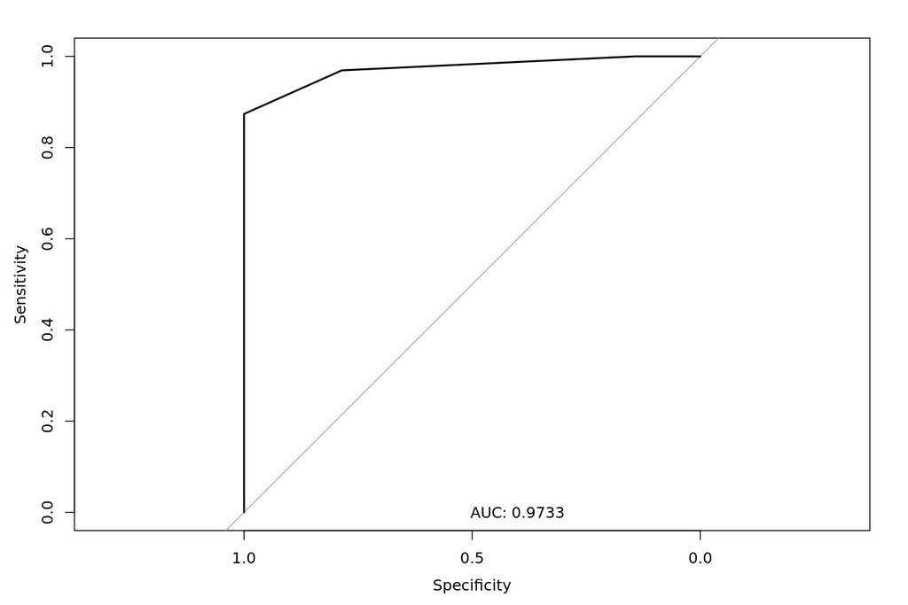

```r
knitr::include_graphics(filename)
```

```r
validation_results[["GSE30219"]] <- NULL
gc()
```